# Simulation of a multi compartment model (passive neurite)

Regarding to Kirchhoff's Current Law it holds for comparment $j$ that: $ \frac{I_e}{A} = C_m \frac{dV}{dt} + \frac{E_L}{R_m}$

The voltage for a compartment $j$ with an input current $I_e$ is therfore given by the DEQ: $C_m \frac{dV}{dt} = -\frac{E_L}{R_m} + \frac{I_e}{A}$

In a multi-compartment model compartment $j$ is connected by an axial resistance $R_a$ to adjoining compartments $j-1$ and $j+1$ with voltages $V_{j-1}$ and $V_{j+1}$. This leads to inflowing currents $\frac{(V_{j-1}-V_j)}{R_a}$ and $\frac{(V_{j+1}-V_j)}{R_a}$.

In order to fullfill the Kirchhoff's Current Law in this case it must hold that: $$\frac{I_e}{A} + \frac{(V_{j-1}-V_j)}{R_a} + \frac{(V_{j+1}-V_j)}{R_a} = C_m \frac{dV}{dt} + \frac{E_L}{R_m}$$ Therefore the voltage in compartment $j$ is given by the DEQ: $$C_m \frac{dV}{dt} = -\frac{E_L}{R_m} + \frac{I_e}{A} + \frac{(V_{j-1}-V_j)}{R_a} + \frac{(V_{j+1}-V_j)}{R_a}$$(in the case that $j$ is an terminal compartment one of these inflowing currents drops)

```python
%matplotlib notebook
import math
import numpy as np
import matplotlib.pyplot as plt
from mpl_toolkits.mplot3d import Axes3D
```

### Compartment Model

```python
def multi_compartment_simulation(N, C_m, R_m, R_a, E_m,input_function, delta_t, t):
    steps = np.arange(0,t,delta_t)
    compartment_potential = np.zeros((N,steps.shape[0])) # initialize with zero



    for j, t in enumerate(steps[:-1]):
        for i in range(1,N-1):  # stop before killed-end compartment
                post  = (compartment_potential[i+1,j] - compartment_potential[i][j])/R_a
                pre = (compartment_potential[i-1,j] - compartment_potential[i][j])/R_a
                current = input_function(i,t) + (E_m - compartment_potential[i][j])/R_m
                deltaV_detlat = (pre +current + post)/C_m
                compartment_potential[i,j+1] = compartment_potential[i,j] + delta_t * deltaV_detlat

        compartment_potential[0,j] = compartment_potential[1,j] # Boundary condition for sealed terminal compartment
    return compartment_potential, steps
```

### Properties and Current Functions

```python
#------------------------------------------Electric Properties---------------------------------------------------------

C_m = 62.8 * 10**-12 # F
R_m = 1.59 * 10**9 # Ohm
R_a = 0.0318 * 10 **9 # Ohm
E_l = E_m = 0 # V

#--------------------------------------------Time Properties-----------------------------------------------------------
delta_t = 0.0001 # seconds
j_e = 20 # Compartment index
t_e = 0.02 # seconds
I_0 = 10*10**-12 # A
t_s = 0.4 # seconds


#------------------------------------------Current Functions-----------------------------------------------------------
def step_current(j,t):
    if(t<t_e or j != j_e):
        return 0
    if(t_e <= t and j==j_e):
        return I_0

def rectangular_current(j,t):
    if(t< t_e or t_s <= t or j != j_e):
        return 0
    if(t_e <= t and t < t_s and j == j_e):
        return 10*I_0
```

### Simulation and Plots

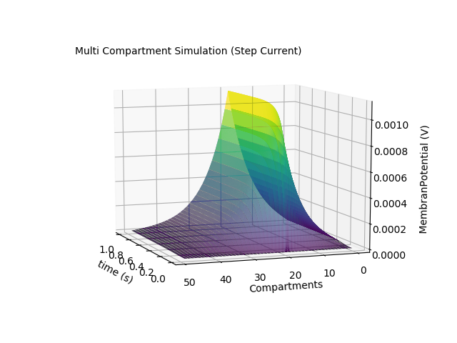

```python
compartment_potential_1, steps_1 = multi_compartment_simulation(52, C_m, R_m, R_a, E_l, step_current, delta_t, 1)
x_1 = [i for i in steps_1]
y_1 = range(50)

X_1, Y_1 = np.meshgrid(x_1, y_1)

fig_1 = plt.figure()


ax_1 = fig_1.add_subplot(111, projection='3d')
ax_1.plot_surface(X_1, Y_1, compartment_potential_1[1:51],rstride=1, cstride=1, cmap='viridis',alpha=1)


ax_1.set_xlabel('time (s)')
ax_1.set_ylabel('Compartments')
ax_1.set_zlabel('\n\n MembranPotential (V)')

ax_1.text2D(0.05, 0.95, "Multi Compartment Simulation (Step Current)", transform=ax_1.transAxes)
ax_1.view_init(10,160)

#ax_1.w_yaxis.line.set_lw(0.)
#ax_1.set_yticks([])
#ax_1.set_ylabel('')
#ax_1.set_zlabel('\n\n\n\n  MembranPotential (V)')
#ax_1.tick_params(axis='z', which='major', pad=15)
#ax_1.view_init(0,-90)


#ax_1.w_xaxis.line.set_lw(0.)
#ax_1.set_xticks([])
#ax_1.set_xlabel('')
#ax_1.set_zlabel('\n\n\n\n  MembranPotential (V)')
#ax_1.tick_params(axis='z', which='major', pad=15)
#ax_1.view_init(0,180)


plt.show()
```

### Discussion

The functional form of the spatially dependent stationary solution shows a two-sided exponential decay with equal slope. The current injected in compartment 20 leads to an increase in voltage in this compartment. From here it equally expends to adjoining compartments in both directions. Looking at the voltage change over time you can see that all compartments follow the same functional form with different amplitudes.

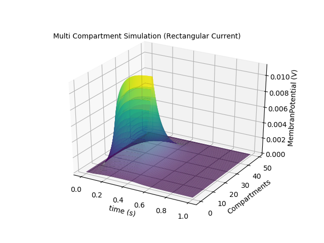

```python
compartment_potential_2, steps_2 = multi_compartment_simulation(50, C_m, R_m, R_a, E_l, rectangular_current, delta_t, 1)
x_2 = [i for i in steps_2]
y_2 = range(50)
X_2, Y_2 = np.meshgrid(x_2, y_2)
fig_2 = plt.figure()
ax_2 = fig_2.add_subplot(111, projection='3d')
ax_2.plot_surface(X_2, Y_2, compartment_potential_2,rstride=1, cstride=1, cmap='viridis')
ax_2.set_xlabel('time (s)')
ax_2.set_ylabel('Compartments')
ax_2.set_zlabel('MembranPotential (V)')

ax_2.zaxis._axinfo['label']['space_factor'] = 5
ax_2.text2D(0.05, 0.95, "Multi Compartment Simulation (Rectangular Current)", transform=ax_2.transAxes)

#ax_2.w_yaxis.line.set_lw(0.)
#ax_2.set_yticks([])
#ax_2.set_ylabel('')
#ax_2.set_zlabel('\n\n\n\n  MembranPotential (V)')
#ax_2.tick_params(axis='z', which='major', pad=15)
#ax_2.view_init(0,-90)

#ax_2.w_xaxis.line.set_lw(0.)
#ax_2.set_xticks([])
#ax_2.set_xlabel('')
#ax_2.set_zlabel('\n\n\n\n  MembranPotential (V)')
#ax_2.tick_params(axis='z', which='major', pad=15)
#ax_2.view_init(0,180)


plt.show()
```